# ChIP-seq Analysis

Carson Stacy & Jeffrey Lewis

Fall 2023

last updated: 2023-11-01

## Description

In this class exercise, we will practice analyzing ChIP-seq data.

## Pre-Analysis Preparations

Before analyzing our ChIP-seq results, we need to prepare our computing environment for this analysis.

### Prepare Software

This analysis will use both R and terminal based commands.

#### R packages

```r
# Ensure required packages are installed
if (!require("pacman")) install.packages("pacman"); library(pacman)
# install if not already installed
if (!require("TxDb.Scerevisiae.UCSC.sacCer3.sgdGene", quietly = TRUE))
  p_install("TxDb.Scerevisiae.UCSC.sacCer3.sgdGene")
if (!require("BSgenome.Scerevisiae.UCSC.sacCer3", quietly = TRUE))
  p_install("BSgenome.Scerevisiae.UCSC.sacCer3")
if (!require("ChIPseeker", quietly = TRUE))
  p_install("ChIPseeker")
```

```
## ChIPseeker v1.38.0
##
## If you use ChIPseeker in published research, please cite:
## Qianwen Wang, Ming Li, Tianzhi Wu, Li Zhan, Lin Li, Meijun Chen, Wenqin Xie, Zijing Xie, Erqiang Hu, Shuangbin Xu, Guangchuang Yu. Exploring epigenomic datasets by ChIPseeker. Current Protocols 2022, 2(10): e585
```

```r
# Load necessary packages
# p_load("tidyverse", "knitr", "readr", "pander", "BiocManager",
#        "dplyr", "stringr", #"purrr", "reactable",
#        "biomaRt", "memes", "Biostrings", "curl", "universalmotif")


p_load("tidyverse", "knitr",
       "Rfastp", "Rsubread",
       "ChIPseeker", "BSgenome.Scerevisiae.UCSC.sacCer3",
       "TxDb.Scerevisiae.UCSC.sacCer3.sgdGene", "curl",
       "AnnotationDbi", "biomaRt",
       "memes", "universalmotif",
       "clusterProfiler", "GenomicRanges",
       "ggimage", "reactable"
       )

# make sure all packages install and load correctly.
library("tidyverse")
library("dplyr")
library("Rfastp")
library("Rsubread")
library("ChIPseeker")
library("memes")
library("universalmotif")
library("reactable")
library("BSgenome.Scerevisiae.UCSC.sacCer3")
library("TxDb.Scerevisiae.UCSC.sacCer3.sgdGene")
library("clusterProfiler")
library("curl")
library("AnnotationDbi")
library("biomaRt")
library("GenomicRanges")
```

#### Conda environments

Similar to exercise 03_Working_with_Sequences.Rmd, we need to use software that aren’t available in R. One way to do that is the way shown here, creating and activating conda environments. If you haven’t done set-up of conda on your system as described in Exercise 03, this code likely won’t run for you.

##### MACS2

A popular software for peak-calling ChIP-seq data is [MACS2](https://pypi.org/project/MACS2/). It uses a Poisson distribution-based model to background identify significant peaks in ChIP-seq data.

```bash
# create an enviornment for our QC packages
if conda info --envs | grep -q MACS; then echo "environment 'MACS' already exists"; else conda create -y -n MACS macs2 -c bioconda; fi

# see available conda environments
conda env list

# activate our MACS environment
conda activate MACS

# make sure desired package is working
which macs2

# get the versions of each software
macs2 --version

# it's always good coding practice to deactivate a conda environment at the end of a chunk
conda deactivate
```

```
## environment 'MACS' already exists
## # conda environments:
## #
##                          /Users/clstacy/Library/r-miniconda
##                          /Users/clstacy/Library/r-miniconda-arm64
##                          /Users/clstacy/Library/r-miniconda-arm64/envs/r-reticulate
##                          /Users/clstacy/Library/r-miniconda/envs/r-reticulate
## base                  *  /Users/clstacy/anaconda3
## MACS                     /Users/clstacy/anaconda3/envs/MACS
## QC                       /Users/clstacy/anaconda3/envs/QC
## mageck                   /Users/clstacy/anaconda3/envs/mageck
## salmon                   /Users/clstacy/anaconda3/envs/salmon
##                          /Users/clstacy/opt/anaconda3
##                          /Users/clstacy/opt/anaconda3/envs/colony_count_nn
##                          /Users/clstacy/opt/anaconda3/envs/tlcc
##
## /Users/clstacy/anaconda3/envs/MACS/bin/macs2
## macs2 2.2.7.1
```

### Data Retreival

#### fastq files

We will be using paired-end fastq files from the publication https://academic.oup.com/nar/article/42/9/5468/1246885, with experiment SRA accession SRP033438. Specifically, we will be getting time 0 minutes and time 20 minutes post glucose to glycerol shift, which induces the ESR. These samples have the names SRR1181480 and SRR1181481 respectively.

We could use the SRA toolkit to download these files (tutorial [here](https://erilu.github.io/python-fastq-downloader/#automating-downloads-using-python)).

An alternative approach we can use to download these files is going to https://www.ebi.ac.uk/ena/browser/view/SRR1181480 and https://www.ebi.ac.uk/ena/browser/view/SRR1181481 to either download the files manually, or download the bash script that we can use to download the files. We will use a modified version of that code to download the files today.

```bash
# Be sure to change this file path to the path you want your data to go
RAW_DATA_DIR="/Users/$USER/Desktop/Genomic_Data_Analysis/Data/Raw/ChIP"
# if you're using Windows 10,
# in RStudio, go to Tools>Global Options... > Terminal > New Terminals open with...
# and choose WSL bash or git bash
# next, use: (be sure to put in the correct username)
#RAW_DATA_DIR="/mnt/c/Users/$USER/Desktop/Genomic_Data_Analysis/Data/Raw"

# create the destination directory if it doesn't already exist
mkdir -p $RAW_DATA_DIR

# change to that directory (for this code chunk only)
cd $RAW_DATA_DIR
pwd
# Download the files.
# WARNING: curl doesn't work with relative paths

# T=0 read 1
if [ ! -f "$RAW_DATA_DIR/SRR1181480_1.fastq.gz" ]; then
    echo "fastq file SRR1181480_1.fastq.gz not found, downloading..."
    # If the file does not exist, download it using curl
    wget -nc ftp://ftp.sra.ebi.ac.uk/vol1/fastq/SRR118/000/SRR1181480/SRR1181480_1.fastq.gz
    echo "Downloading finished"
else
    echo "File SRR1181480_1.fastq.gz already exists at $RAW_DATA_DIR Skipping download."
fi

#T=0 read 2
if [ ! -f "$RAW_DATA_DIR/SRR1181480_2.fastq.gz" ]; then
    echo "fastq file SRR1181480_2.fastq.gz not found, downloading..."
    # If the file does not exist, download it using curl
    wget -nc ftp://ftp.sra.ebi.ac.uk/vol1/fastq/SRR118/000/SRR1181480/SRR1181480_2.fastq.gz
    echo "Downloading finished"
else
    echo "File SRR1181480_2.fastq.gz already exists at $RAW_DATA_DIR Skipping download."
fi

# T=20 read 1
if [ ! -f "$RAW_DATA_DIR/SRR1181481_1.fastq.gz" ]; then
    echo "fastq file SRR1181481_1.fastq.gz not found, downloading..."
    # If the file does not exist, download it using curl
    wget -nc ftp://ftp.sra.ebi.ac.uk/vol1/fastq/SRR118/001/SRR1181481/SRR1181481_1.fastq.gz
    echo "Downloading finished"
else
    echo "File SRR1181481_1.fastq.gz already exists at $RAW_DATA_DIR Skipping download."
fi

#T=20 read 2
if [ ! -f "$RAW_DATA_DIR/SRR1181481_2.fastq.gz" ]; then
    echo "fastq file SRR1181481_2.fastq.gz not found, downloading..."
    # If the file does not exist, download it using curl
    wget -nc ftp://ftp.sra.ebi.ac.uk/vol1/fastq/SRR118/001/SRR1181481/SRR1181481_2.fastq.gz
    echo "Downloading finished"
else
    echo "File SRR1181481_2.fastq.gz already exists at $RAW_DATA_DIR Skipping download."
fi

# see all downloaded files
ls -lah
```

```
## /Users/clstacy/Desktop/Genomic_Data_Analysis/Data/Raw/ChIP
## File SRR1181480_1.fastq.gz already exists at /Users/clstacy/Desktop/Genomic_Data_Analysis/Data/Raw/ChIP Skipping download.
## File SRR1181480_2.fastq.gz already exists at /Users/clstacy/Desktop/Genomic_Data_Analysis/Data/Raw/ChIP Skipping download.
## File SRR1181481_1.fastq.gz already exists at /Users/clstacy/Desktop/Genomic_Data_Analysis/Data/Raw/ChIP Skipping download.
## File SRR1181481_2.fastq.gz already exists at /Users/clstacy/Desktop/Genomic_Data_Analysis/Data/Raw/ChIP Skipping download.
## total 1177192
## drwxr-xr-x@  6 clstacy  staff   192B Oct 30 10:17 .
## drwxr-xr-x@ 20 clstacy  staff   640B Oct 30 10:24 ..
## -rw-r--r--@  1 clstacy  staff   148M Oct 30 10:17 SRR1181480_1.fastq.gz
## -rw-r--r--@  1 clstacy  staff   145M Oct 30 10:18 SRR1181480_2.fastq.gz
## -rw-r--r--@  1 clstacy  staff   143M Oct 30 10:15 SRR1181481_1.fastq.gz
## -rw-r--r--@  1 clstacy  staff   140M Oct 30 10:16 SRR1181481_2.fastq.gz
```

#### Reference files

#####**Genome**

```bash
# Define the destination file path
# You can change this file path to the path you want your data to go, or leave it.
REF_DIR="/Users/$USER/Desktop/Genomic_Data_Analysis/Reference"

# make that directory if it doesn't already
mkdir -p $REF_DIR

# Define the URL of reference genome
# (latest from ensembl)
url="ftp://ftp.ensembl.org/pub/release-110/fasta/saccharomyces_cerevisiae/dna/Saccharomyces_cerevisiae.R64-1-1.dna.toplevel.fa.gz"


# Check if the file already exists at the destination location
if [ ! -f "$REF_DIR/Saccharomyces_cerevisiae.R64-1-1.dna.toplevel.fa.gz" ]; then
    echo "Reference genome not found, downloading..."
    # If the file does not exist, download it using curl
    curl -o "$REF_DIR/Saccharomyces_cerevisiae.R64-1-1.dna.toplevel.fa.gz" "$url"
    echo "Downloading finished"
else
    echo "File already exists at $REF_DIR Skipping download."
fi
```

```
## File already exists at /Users/clstacy/Desktop/Genomic_Data_Analysis/Reference Skipping download.
```

#####**blacklist**

ChIPseq will often show the presence of common artifacts, such as ultra-high signal regions. Such regions can confound peak calling, fragment length estimation and QC metrics. Anshul Kundaje created the DAC blacklist as a reference to help deal with these regions. These are available for dm3, dm6, ce10, ce11, mm10, hg19, and hg38. (https://zenodo.org/records/1491733).

*Saccharomyces cerevisiae* doesn’t have an official blacklist, so we won’t be using this today.

### QC & Trimming

Get paths to all of our read files, split by read 1 and read 2.

```r
# assign directory with the raw fastq files
fq_file_dir <- path.expand("~/Desktop/Genomic_Data_Analysis/Data/Raw/ChIP")

# assign read 1 and read 2 paths into objects
fq_read1_files <- list.files(fq_file_dir, full.names = TRUE, pattern = "*_1.fastq.gz")
fq_read2_files <- list.files(fq_file_dir, full.names = TRUE, pattern = "*_2.fastq.gz")
```

#### Trim with rfastp

We can use rfastp to trim and QC all of our files, by slightly modifying the original rfastp command we used for rnaseq data. The only major modification is including the read2 in rfastp. QC reports and trimmed fastq files will appear in the dir_trimmed.fq_files folder.

```r
# create a directory for the output to go into if not already present
dir_trimmed.fq_files <- path.expand("~/Desktop/Genomic_Data_Analysis/Data/Trimmed/ChIP")
if (!dir.exists(dir_trimmed.fq_files)) {dir.create(dir_trimmed.fq_files, recursive = TRUE)}

# run rfastp on all fastq files
for (i in 1:length(fq_read1_files)) {
  # file path to each file for paired end reads
  read1 <- fq_read1_files[i]
  read2 <- fq_read2_files[i]
  # assign output file (putting it inside of dir_trimmed.fq_files folder)
  output_name <- paste0(dir_trimmed.fq_files,
                        "/",
                        basename(fq_read1_files[i])) |>
                          str_replace("_1", "")
  json_report <- rfastp(
    read1 = read1,
    read2 = read2,
    outputFastq = str_split(output_name, fixed("."))[[1]][1],
    disableTrimPolyG = FALSE,
    cutLowQualFront = TRUE,
    cutLowQualTail = TRUE,
    minReadLength = 15
  )

  # Print the output file link in the R Markdown document
  cat(paste0(
    "[Processing Complete - ",
    basename(output_name),
    "](",
    output_name,
    ")\n\n"
  ))
}
```

```
## [Processing Complete - SRR1181480.fastq.gz](/Users/clstacy/Desktop/Genomic_Data_Analysis/Data/Trimmed/ChIP/SRR1181480.fastq.gz)
##
## [Processing Complete - SRR1181481.fastq.gz](/Users/clstacy/Desktop/Genomic_Data_Analysis/Data/Trimmed/ChIP/SRR1181481.fastq.gz)
```

### Map to Reference

Assign the read1 trimmed fastq files to a list in R called trimmed_fastq_files_R1, and we’ll do the same for read2 fastq files.

```r
# find our trimmed fastq files
trimmed_fastq_files_R1 <- list.files(path = dir_trimmed.fq_files,
                                  pattern = "_R1.fastq.gz$",
                                  full.names = TRUE)


trimmed_fastq_files_R2 <- list.files(path = dir_trimmed.fq_files,
                                  pattern = "_R2.fastq.gz$",
                                  full.names = TRUE)

# print them out
trimmed_fastq_files_R1
```

```
## [1] "/Users/clstacy/Desktop/Genomic_Data_Analysis/Data/Trimmed/ChIP/SRR1181480_R1.fastq.gz"
## [2] "/Users/clstacy/Desktop/Genomic_Data_Analysis/Data/Trimmed/ChIP/SRR1181481_R1.fastq.gz"
```

```r
trimmed_fastq_files_R2
```

```
## [1] "/Users/clstacy/Desktop/Genomic_Data_Analysis/Data/Trimmed/ChIP/SRR1181480_R2.fastq.gz"
## [2] "/Users/clstacy/Desktop/Genomic_Data_Analysis/Data/Trimmed/ChIP/SRR1181481_R2.fastq.gz"
```

#### Build Genome Index for Rsubread

We have already done this in the Read_mapping.Rmd exercise. If you’ve already created this, we can skip this step.

```r
# Set path of the reference fasta file
reference_genome = path.expand("~/Desktop/Genomic_Data_Analysis/Reference/Saccharomyces_cerevisiae.R64-1-1.dna.toplevel.fa.gz")

index_reference_genome = path.expand("~/Desktop/Genomic_Data_Analysis/Reference/index_rsubread_Saccharomyces_cerevisiae.R64-1-1")

# build the index
buildindex(basename=index_reference_genome, reference=reference_genome)
```

[output not shown]

[output cut: 26 more lines]

[output not shown]

#### Align trimmed files to the reference genome.

```r
# run the alignment on all of the trimmed_fastq_files
align(index=index_reference_genome,
      readfile1=trimmed_fastq_files_R1,
      readfile2=trimmed_fastq_files_R2,
      type = "dna",
      input_format = "gzFASTQ",
      output_format = "BAM",
      unique = TRUE,
      nBestLocations = 1,
      sortReadsByCoordinates = TRUE,
      nthreads=6
      )
```

```
##
##         ==========     _____ _    _ ____  _____  ______          _____
##         =====         / ____| |  | |  _ \|  __ \|  ____|   /\   |  __ \
##           =====      | (___ | |  | | |_) | |__) | |__     /  \  | |  | |
##             ====      \___ \| |  | |  _ <|  _  /|  __|   / /\ \ | |  | |
##               ====    ____) | |__| | |_) | | \ \| |____ / ____ \| |__| |
##         ==========   |_____/ \____/|____/|_|  \_\______/_/    \_\_____/
##        Rsubread 2.16.0
##
## //================================= setting ==================================\\
## ||                                                                            ||
## || Function      : Read alignment (DNA-Seq)                                   ||
## || Input file 1  : SRR1181480_R1.fastq.gz                                     ||
## || Input file 2  : SRR1181480_R2.fastq.gz                                     ||
## || Output file   : SRR1181480_R1.fastq.gz.subread.BAM (BAM), Sorted           ||
## || Index name    : index_rsubread_Saccharomyces_cerevisiae.R64-1-1            ||
## ||                                                                            ||
## ||                    ------------------------------------                    ||
## ||                                                                            ||
## ||                               Threads : 6                                  ||
## ||                          Phred offset : 33                                 ||
## ||               # of extracted subreads : 10                                 ||
## ||                        Min read1 vote : 3                                  ||
## ||                        Min read2 vote : 1                                  ||
## ||                     Max fragment size : 600                                ||
## ||                     Min fragment size : 50                                 ||
## ||                        Max mismatches : 3                                  ||
## ||                      Max indel length : 5                                  ||
## ||            Report multi-mapping reads : no                                 ||
## || Max alignments per multi-mapping read : 1                                  ||
## ||                                                                            ||
## \\============================================================================//
##
## //================ Running (01-Nov-2023 20:15:07, pid=59839) =================\\
## ||                                                                            ||
## || Check the input reads.                                                     ||
## || The input file contains base space reads.                                  ||
## || Initialise the memory objects.                                             ||
## || Estimate the mean read length.                                             ||
## || The range of Phred scores observed in the data is [2,41]                   ||
```

[output cut: 134 more lines]

```
## ||                    Unmapped : 638,153                                      ||
## ||                                                                            ||
## ||             Properly paired : 347,876                                      ||
## ||         Not properly paired : 74,241                                       ||
## ||                   Singleton : 57,241                                       ||
## ||                    Chimeric : 5,376                                        ||
## ||       Unexpected strandness : 1,713                                        ||
## ||  Unexpected fragment length : 5,273                                        ||
## ||       Unexpected read order : 4,638                                        ||
## ||                                                                            ||
## ||                      Indels : 2,582                                        ||
## ||                                                                            ||
## ||                Running time : 4.0 minutes                                  ||
## ||                                                                            ||
## \\============================================================================//
```

```
##                                 SRR1181480_R1.fastq.gz.subread.BAM
## Total_fragments                                            1160392
## Mapped_fragments                                            402860
## Uniquely_mapped_fragments                                   402860
## Multi_mapping_fragments                                          0
## Unmapped_fragments                                          757532
## Properly_paired_fragments                                   334707
## Singleton_fragments                                          51547
## More_than_one_chr_fragments                                   6009
## Unexpected_strandness_fragments                               2340
## Unexpected_template_length                                    4275
## Inversed_mapping                                              3982
## Indels                                                        1914
##                                 SRR1181481_R1.fastq.gz.subread.BAM
## Total_fragments                                            1060270
## Mapped_fragments                                            422117
## Uniquely_mapped_fragments                                   422117
## Multi_mapping_fragments                                          0
## Unmapped_fragments                                          638153
## Properly_paired_fragments                                   347876
## Singleton_fragments                                          57241
## More_than_one_chr_fragments                                   5376
## Unexpected_strandness_fragments                               1713
## Unexpected_template_length                                    5273
## Inversed_mapping                                              4638
## Indels                                                        2582
```

```r
# Create new directory to store mapping .bam files
dir_bam_files <- path.expand("~/Desktop/Genomic_Data_Analysis/Data/Bam/ChIP")
if (!dir.exists(dir_bam_files)) {dir.create(dir_bam_files, recursive = TRUE)}
```

Move output files into bam file directory

```bash
trim_fq_dir=~/Desktop/Genomic_Data_Analysis/Data/Trimmed/ChIP
bam_dir=~/Desktop/Genomic_Data_Analysis/Data/Bam/ChIP/
mv $trim_fq_dir/*.BAM* $bam_dir
```

Save the paths to our bam files as an object.

```r
bam_files <- list.files(path = dir_bam_files, pattern = ".BAM$", full.names = TRUE)
bam_files
```

```
## [1] "/Users/clstacy/Desktop/Genomic_Data_Analysis/Data/Bam/ChIP/SRR1181480_R1.fastq.gz.subread.BAM"
## [2] "/Users/clstacy/Desktop/Genomic_Data_Analysis/Data/Bam/ChIP/SRR1181480_R2.fastq.gz.subread.BAM"
## [3] "/Users/clstacy/Desktop/Genomic_Data_Analysis/Data/Bam/ChIP/SRR1181481_R1.fastq.gz.subread.BAM"
## [4] "/Users/clstacy/Desktop/Genomic_Data_Analysis/Data/Bam/ChIP/SRR1181481_R2.fastq.gz.subread.BAM"
```

## Peak Calling

Now, we are able to call peaks with MACS2.

To run MACS2 to we need to supply:

```
1. A BAM file to find enriched regions in. (specified after -t)
  a. (this is the only REQUIRED parameter for MACS)
2. A Name for peak calls (specified after –name).
3. An output folder to write peaks into (specified after –outdir).
4. Optionally, but highly recommended, we can identify a control to compare to (specified after –c).
```

In this analysis, we only need to do a single call to macs2 because we only have one treatment sample and one control sample. If we had more samples, we’d want to run macs2 for every sample.

For the purpose of demonstration, we will run macs2 on each sample with no control. THIS IS NOT RECOMMENDED. For this analysis, we should just use the third call to macs2 below. We are running the calling without controls so we can look at the peaks that would be called for each alone, so we can compare them to the peaks of the treatment vs control.

Flags we’ve used for MACS2:

```
- `-n` output file name prefix
- `--outdir` path to where output files should be saved
- `f` type of files being input. Usually `BAM` (or `BAMPE` for paired-end.)
- `g` is the genome size. this has been set for yeast genome
- `B` output bedgraph files
- `--nomodel` MACS will bypass building the shifting model.
- `extsize` While --nomodel is set, MACS uses this parameter to extend reads in 5'->3' direction to fix-sized fragments.
```

```bash
# activate our MACS environment
conda activate MACS

macs_outdir=/Users/$USER/Desktop/Genomic_Data_Analysis/Analysis/ChIP/

# run macs on the 0 minutes sample, no control
macs2 callpeak -t "/Users/$USER/Desktop/Genomic_Data_Analysis/Data/Bam/ChIP/SRR1181480_R1.fastq.gz.subread.BAM" \
  -n MSN24_ESR_t0_noControl \
  --outdir $macs_outdir \
  -f BAMPE \
  -g 1.2e7 \
  -B \
  --nomodel \
  --extsize 50


# run macs on the 20 minutes sample, no control
macs2 callpeak -t "/Users/$USER/Desktop/Genomic_Data_Analysis/Data/Bam/ChIP/SRR1181481_R1.fastq.gz.subread.BAM" \
               -n MSN24_ESR_t20_noControl \
               --outdir $macs_outdir \
               -f BAMPE \
               -g 1.2e7 \
               -B \
               --nomodel \
               --extsize 50


# run macs with 20 min as treatment and 0 min as control
macs2 callpeak -t "/Users/$USER/Desktop/Genomic_Data_Analysis/Data/Bam/ChIP/SRR1181481_R1.fastq.gz.subread.BAM" \
               -n MSN24_ESR_t20vst0 \
               -c "/Users/$USER/Desktop/Genomic_Data_Analysis/Data/Bam/ChIP/SRR1181480_R1.fastq.gz.subread.BAM" \
               --outdir $macs_outdir \
               -B \
               -f BAMPE \
               -g 1.2e7



# Rename all *.bdg to *.bedgraph for IGV visualization
for file in ${macs_outdir}*.bdg; do
   mv -- "$file" "${file%.bdg}.bedgraph"
done
```

```
## INFO  @ Wed, 01 Nov 2023 20:24:27:
## # Command line: callpeak -t /Users/clstacy/Desktop/Genomic_Data_Analysis/Data/Bam/ChIP/SRR1181480_R1.fastq.gz.subread.BAM -n MSN24_ESR_t0_noControl --outdir /Users/clstacy/Desktop/Genomic_Data_Analysis/Analysis/ChIP/ -f BAMPE -g 1.2e7 -B --nomodel --extsize 50
## # ARGUMENTS LIST:
## # name = MSN24_ESR_t0_noControl
## # format = BAMPE
## # ChIP-seq file = ['/Users/clstacy/Desktop/Genomic_Data_Analysis/Data/Bam/ChIP/SRR1181480_R1.fastq.gz.subread.BAM']
## # control file = None
## # effective genome size = 1.20e+07
## # band width = 300
## # model fold = [5, 50]
## # qvalue cutoff = 5.00e-02
## # The maximum gap between significant sites is assigned as the read length/tag size.
## # The minimum length of peaks is assigned as the predicted fragment length "d".
## # Larger dataset will be scaled towards smaller dataset.
## # Range for calculating regional lambda is: 10000 bps
## # Broad region calling is off
## # Paired-End mode is on
##
## INFO  @ Wed, 01 Nov 2023 20:24:27: #1 read fragment files...
## INFO  @ Wed, 01 Nov 2023 20:24:27: #1 read treatment fragments...
## INFO  @ Wed, 01 Nov 2023 20:24:31: 334707 fragments have been read.
## INFO  @ Wed, 01 Nov 2023 20:24:31: #1 mean fragment size is determined as 208.8 bp from treatment
## INFO  @ Wed, 01 Nov 2023 20:24:31: #1 fragment size = 208.8
## INFO  @ Wed, 01 Nov 2023 20:24:31: #1  total fragments in treatment: 334707
## INFO  @ Wed, 01 Nov 2023 20:24:31: #1 user defined the maximum fragments...
## INFO  @ Wed, 01 Nov 2023 20:24:31: #1 filter out redundant fragments by allowing at most 1 identical fragment(s)
## INFO  @ Wed, 01 Nov 2023 20:24:32: #1  fragments after filtering in treatment: 286038
## INFO  @ Wed, 01 Nov 2023 20:24:32: #1  Redundant rate of treatment: 0.15
## INFO  @ Wed, 01 Nov 2023 20:24:32: #1 finished!
## INFO  @ Wed, 01 Nov 2023 20:24:32: #2 Build Peak Model...
## INFO  @ Wed, 01 Nov 2023 20:24:32: #2 Skipped...
## INFO  @ Wed, 01 Nov 2023 20:24:32: #3 Call peaks...
## INFO  @ Wed, 01 Nov 2023 20:24:32: #3 Pre-compute pvalue-qvalue table...
## INFO  @ Wed, 01 Nov 2023 20:24:33: #3 In the peak calling step, the following will be performed simultaneously:
## INFO  @ Wed, 01 Nov 2023 20:24:33: #3   Write bedGraph files for treatment pileup (after scaling if necessary)... MSN24_ESR_t0_noControl_treat_pileup.bdg
## INFO  @ Wed, 01 Nov 2023 20:24:33: #3   Write bedGraph files for control lambda (after scaling if necessary)... MSN24_ESR_t0_noControl_control_lambda.bdg
## INFO  @ Wed, 01 Nov 2023 20:24:33: #3   Pileup will be based on sequencing depth in treatment.
## INFO  @ Wed, 01 Nov 2023 20:24:33: #3 Call peaks for each chromosome...
## INFO  @ Wed, 01 Nov 2023 20:24:34: #4 Write output xls file... /Users/clstacy/Desktop/Genomic_Data_Analysis/Analysis/ChIP/MSN24_ESR_t0_noControl_peaks.xls
## INFO  @ Wed, 01 Nov 2023 20:24:34: #4 Write peak in narrowPeak format file... /Users/clstacy/Desktop/Genomic_Data_Analysis/Analysis/ChIP/MSN24_ESR_t0_noControl_peaks.narrowPeak
```

[output cut: 79 more lines]

```
## INFO  @ Wed, 01 Nov 2023 20:24:50: #1  Redundant rate of control: 0.15
## INFO  @ Wed, 01 Nov 2023 20:24:50: #1 finished!
## INFO  @ Wed, 01 Nov 2023 20:24:50: #2 Build Peak Model...
## INFO  @ Wed, 01 Nov 2023 20:24:50: #2 Skipped...
## INFO  @ Wed, 01 Nov 2023 20:24:50: #3 Call peaks...
## INFO  @ Wed, 01 Nov 2023 20:24:50: #3 Pre-compute pvalue-qvalue table...
## INFO  @ Wed, 01 Nov 2023 20:24:53: #3 In the peak calling step, the following will be performed simultaneously:
## INFO  @ Wed, 01 Nov 2023 20:24:53: #3   Write bedGraph files for treatment pileup (after scaling if necessary)... MSN24_ESR_t20vst0_treat_pileup.bdg
## INFO  @ Wed, 01 Nov 2023 20:24:53: #3   Write bedGraph files for control lambda (after scaling if necessary)... MSN24_ESR_t20vst0_control_lambda.bdg
## INFO  @ Wed, 01 Nov 2023 20:24:53: #3   Pileup will be based on sequencing depth in treatment.
## INFO  @ Wed, 01 Nov 2023 20:24:53: #3 Call peaks for each chromosome...
## INFO  @ Wed, 01 Nov 2023 20:24:55: #4 Write output xls file... /Users/clstacy/Desktop/Genomic_Data_Analysis/Analysis/ChIP/MSN24_ESR_t20vst0_peaks.xls
## INFO  @ Wed, 01 Nov 2023 20:24:55: #4 Write peak in narrowPeak format file... /Users/clstacy/Desktop/Genomic_Data_Analysis/Analysis/ChIP/MSN24_ESR_t20vst0_peaks.narrowPeak
## INFO  @ Wed, 01 Nov 2023 20:24:55: #4 Write summits bed file... /Users/clstacy/Desktop/Genomic_Data_Analysis/Analysis/ChIP/MSN24_ESR_t20vst0_summits.bed
## INFO  @ Wed, 01 Nov 2023 20:24:55: Done!
```

## Working with Peaks in R

We can use R to analyze the peaks generated by macs2. There are many approaches for doing this. We will use the `ChIPSeeker` package, followed by tools we’ve previously used for downstream analysis.

### Importing Peaks

MACS peak calls can be found in our specified output directory with the suffix and extension “_peaks.xls”. MACS peaks come as a tab separated file (thinly disguised as a “.xls”). In addition to the genomic coordinates of peaks, these files contain useful information on the samples, parameters and version used for peak calling at the top.

```r
MSN24_ESR_t20vst0_peaks <- read.delim("~/Desktop/Genomic_Data_Analysis/Analysis/ChIP/MSN24_ESR_t20vst0_peaks.xls", header = TRUE, comment.char = "#") |>
  # filter on significance of peaks
  filter(X.log10.pvalue. > 5) |>
  # filter on magnitude of enrichment
  filter(fold_enrichment > 4)
```

### Filtering **blacklisted** regions

No peaks were detected in the blacklisted region, so none are filtered out. If you have blacklist regions in your genome, you can remove them now. A variety of software tools are available for excluding them automatically, including bedtools intersect.

```r
# MSN24_ESR_t20vst0_peaks_filtered <- MSN24_ESR_t20vst0_peaks %>%
#   filter(chr != "XII" | end <= 451787 | start >= 468932)
```

### Peak annotation

Currently, we have peaks loaded in as a data.frame object `MSN24_ESR_t20vst0_peaks`. Note that none of the columns in that file tell us which gene(s) each peak corresponds to. In order to do annotate the peaks, we first need to convert out data frame to a GRanges object from the GenomicRanges package.

```r
# Convert dataframe to GRanges object
MSN24_ESR_t20vst0_peaks_GR <-
  GenomicRanges::GRanges(
    seqnames = MSN24_ESR_t20vst0_peaks %>%
      # for this data, need to convert chromosome format to match, done below:
      mutate(chr = paste0("chr", chr)) %>% pull(chr),
    IRanges(MSN24_ESR_t20vst0_peaks[, "start"], MSN24_ESR_t20vst0_peaks[, "end"])
  )
```

Next, we need to load the TxDb for *S. cerevisiae*. The `GenomicFeatures` package uses TxDb objects to store transcript metadata. This contains information about the 5’ and 3’ untranslated regions (UTRs), protein coding sequences (CDSs) and exons for a set of mRNA transcripts to their associated genome. TxDb objects have numerous accessors functions to allow such features to be retrieved individually or grouped together in a way that reflects the underlying biology.

A list of currently available TxDb’s is available at https://bioconductor.org/packages/release/BiocViews.html#___TxDb

```r
# The way we installed this was from BioConductor, with the install code copied below
# BiocManager::install("TxDb.Scerevisiae.UCSC.sacCer3.sgdGene")
txdb <- TxDb.Scerevisiae.UCSC.sacCer3.sgdGene
```

Now that we have a GRanges object and our TxDb object, we can use the `annotatePeak` function from the `ChIPseeker` package to create an object containing the annotated peaks

```r
peakAnno <- ChIPseeker::annotatePeak(MSN24_ESR_t20vst0_peaks_GR, tssRegion=c(-3000, 3000), level = "gene",
                         TxDb=txdb)
```

```
## >> preparing features information...      2023-11-01 20:24:55
## >> identifying nearest features...        2023-11-01 20:24:55
## >> calculating distance from peak to TSS...   2023-11-01 20:24:56
## >> assigning genomic annotation...        2023-11-01 20:24:56
## >> assigning chromosome lengths           2023-11-01 20:24:57
## >> done...                    2023-11-01 20:24:57
```

```r
# See the information this object contains
peakAnno |> data.frame() |> glimpse()
```

```
## Rows: 210
## Columns: 13
## $ seqnames      <fct> chrI, chrI, chrI, chrI, chrII, chrII, chrII, chrII, chrI…
## $ start         <int> 68777, 84997, 139567, 141040, 43563, 140414, 151441, 251…
## $ end           <int> 69349, 85348, 140696, 141870, 43923, 140752, 151791, 251…
## $ width         <int> 573, 352, 1130, 831, 361, 339, 351, 240, 355, 917, 343, …
## $ strand        <fct> *, *, *, *, *, *, *, *, *, *, *, *, *, *, *, *, *, *, *,…
## $ annotation    <chr> "Promoter (<=1kb)", "Promoter (<=1kb)", "Promoter (<=1kb…
## $ geneChr       <int> 1, 1, 1, 1, 2, 2, 2, 2, 2, 2, 2, 2, 2, 2, 3, 3, 3, 3, 3,…
## $ geneStart     <int> 68716, 84669, 140760, 139503, 43174, 138341, 150447, 248…
## $ geneEnd       <int> 69525, 84977, 141407, 141431, 43482, 140260, 151220, 251…
## $ geneLength    <int> 810, 309, 648, 1929, 309, 1920, 774, 2211, 3498, 645, 39…
## $ geneStrand    <int> 2, 1, 1, 2, 2, 2, 2, 2, 2, 1, 2, 1, 2, 2, 1, 1, 2, 1, 1,…
## $ geneId        <chr> "YAL039C", "YAL031W-A", "YAL004W", "YAL005C", "YBL096C",…
## $ distanceToTSS <dbl> 176, 328, -64, 0, -81, -154, -221, -384, 1355, -249, -52…
```

## Visualization

The `ChIPSeeker` package in R contains some functions for visualizing the annotated peaks. We can look at some here.

We see from this pie chart that most of the peaks occurred within 1kb of the TSS for the corresponding gene, with less than 3% of peaks further away.

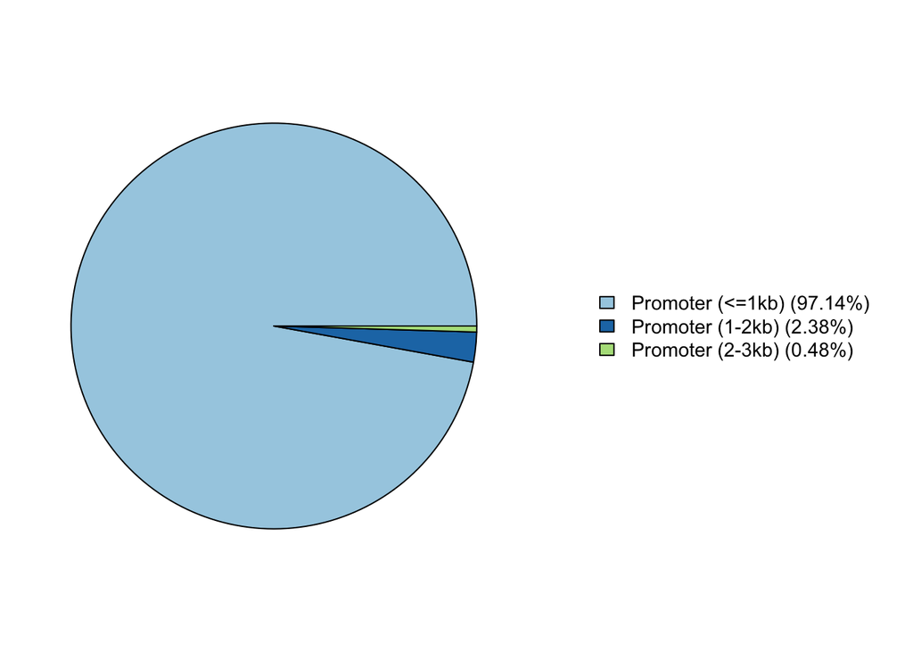

```r
plotAnnoPie(peakAnno)
```

However, we know many features overlap, so we can use a vennpie instead. This shows us that of our peaks extend into regions that contain genes.

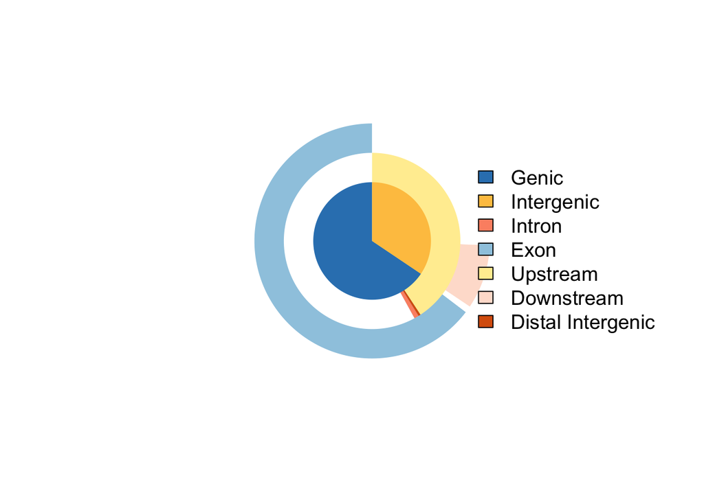

```r
vennpie(peakAnno)
```

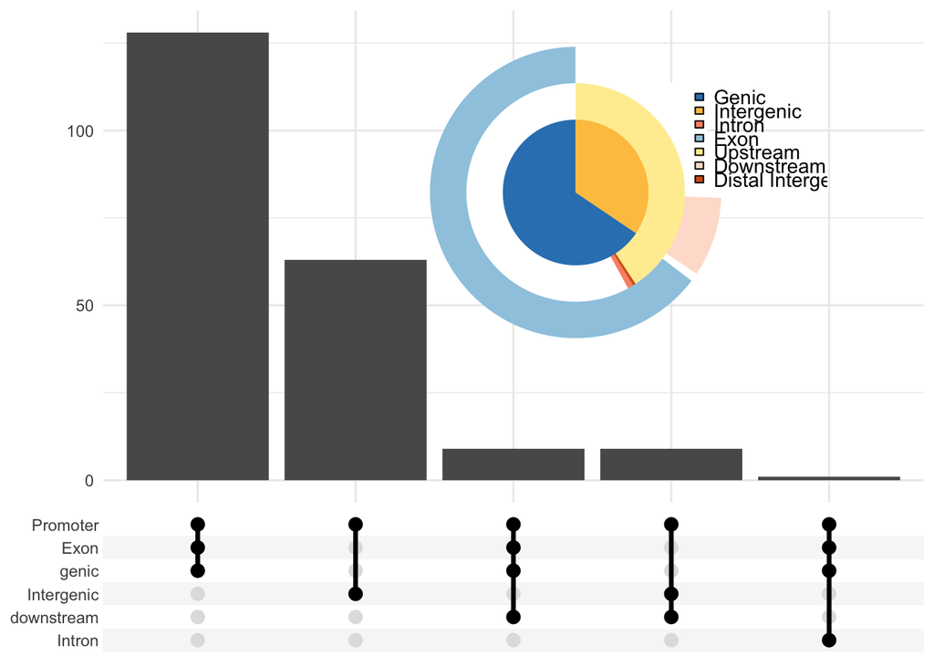

```r
upsetplot(peakAnno, vennpie=TRUE)
```

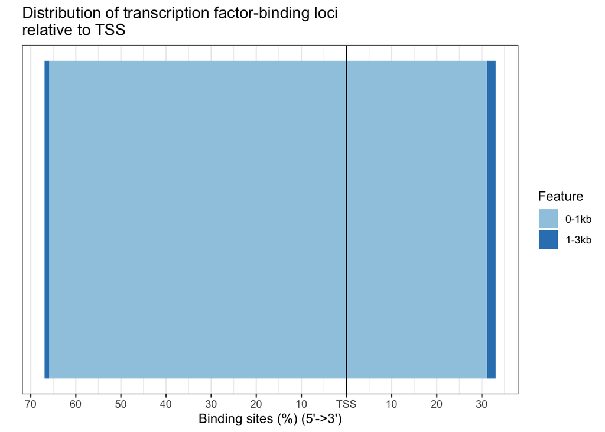

```r
plotDistToTSS(peakAnno,
              title="Distribution of transcription factor-binding loci\nrelative to TSS")
```

### Assess Alignment with IGV

Another method for assessing the quality of your alignment is to visualize the alignment using a genome browser. For this workshop we will be using the Integrative Genomics Viewer (IGV) from the Broad Institute. You may already have this downloaded on your laptop. Alternatively, we can use the web-based IGV to visualize the data.

Go to https://igv.org/app/, select genome as sacCer3, and upload file via Tracks > local file…, and select the MSN24_ESR_t20vst0_treat_pileup.bedgraph (by default in ~/Desktop/Genomic_Data_Analysis/Analysis/ChIP). You can also upload the .bed file in the same folder.

## Downstream Analysis

ChIP peaks in R: Let’s generate a gene list corresponding to peaks that appear in t20 minutes but not t0 minutes. We already have the peaks annotated to genes, so we just need to get a list of genes.

We can extract the unique names of genes with peaks in their TSS by subsetting the annotated GRanges and retrieving gene names from the geneId column.

```r
peak_genes <- peakAnno |>
  as.data.frame() |>
  pull(geneId)

glimpse(peak_genes)
```

```
##  chr [1:210] "YAL039C" "YAL031W-A" "YAL004W" "YAL005C" "YBL096C" "YBL042C" ...
```

### Gene Set Enrichment

Now we have a list of genes that correspond to the peaks seen in treatment but not control. Let’s see if there are any enrichments in this gene list, using techniques we have used already in class.

#### Gene Ontology

We’ll use `enrichGO` from `clusterProfiler` just as we did in the gene ontology lesson.

```r
# Run GO enrichment
go_results <- clusterProfiler::enrichGO(
  gene = peak_genes,
  OrgDb = "org.Sc.sgd.db",
  keyType = "ORF",
  ont = "ALL"
) |>
  # let's add a 'richFactor' column that gives us the proportion of genes DE in the term
  mutate(richFactor = Count / as.numeric(sub("/\\d+", "", BgRatio)))
# take a peak at the results
head(go_results)
```

```
##            ONTOLOGY         ID                                    Description
## GO:0016051       BP GO:0016051              carbohydrate biosynthetic process
## GO:0042542       BP GO:0042542                  response to hydrogen peroxide
## GO:0006091       BP GO:0006091 generation of precursor metabolites and energy
## GO:0006096       BP GO:0006096                             glycolytic process
## GO:0006090       BP GO:0006090                     pyruvate metabolic process
## GO:0009266       BP GO:0009266               response to temperature stimulus
##            GeneRatio  BgRatio       pvalue    p.adjust      qvalue
## GO:0016051    13/185  90/6424 1.451080e-06 0.001435118 0.001377762
## GO:0042542     5/185  13/6424 2.001830e-05 0.007745091 0.007435551
## GO:0006091    19/185 226/6424 2.349370e-05 0.007745091 0.007435551
## GO:0006096     6/185  29/6424 1.437880e-04 0.026393725 0.025338875
## GO:0006090     7/185  41/6424 1.438150e-04 0.026393725 0.025338875
## GO:0009266     9/185  70/6424 1.601237e-04 0.026393725 0.025338875
##                                                                                                                                                             geneID
## GO:0016051                                                 YBR126C/YCR012W/YDR074W/YEL011W/YFR015C/YGL062W/YKL060C/YKL035W/YLR258W/YLR342W/YML100W/YMR135C/YOL126C
## GO:0042542                                                                                                               YDR171W/YGR088W/YJL101C/YOL081W/YOL052C-A
## GO:0006091 YCL040W/YCR012W/YIL057C/YEL011W/YFR015C/YFR053C/YGL055W/YGR254W/YJL045W/YJR120W/YKL109W/YKL060C/YKL035W/YLR258W/YMR145C/YMR315W/YOL126C/YOR136W/YOR344C
## GO:0006096                                                                                                         YCL040W/YCR012W/YFR053C/YGR254W/YKL060C/YOR344C
## GO:0006090                                                                                                 YCL040W/YCR012W/YFR053C/YGL062W/YGR254W/YKL060C/YOR344C
## GO:0009266                                                                               YBR072W/YBR126C/YDR074W/YDR171W/YFL014W/YGR086C/YOL081W/YOL052C-A/YPL240C
##            Count richFactor
## GO:0016051    13  0.1444444
## GO:0042542     5  0.3846154
## GO:0006091    19  0.0840708
## GO:0006096     6  0.2068966
## GO:0006090     7  0.1707317
## GO:0009266     9  0.1285714
```

```r
# create a table for the html file
data.frame(go_results) %>% reactable::reactable()
```

|  | ONTOLOGY | ID | Description | GeneRatio | BgRatio | pvalue | p.adjust | qvalue | geneID | Count | richFactor |
| --- | --- | --- | --- | --- | --- | --- | --- | --- | --- | --- | --- |
| GO:0016051 | BP | GO:0016051 | carbohydrate biosynthetic process | 13/185 | 90/6424 | 1.45108017623508e-06 | 0.0014351182942965 | 0.00137776244101478 | YBR126C/YCR012W/YDR074W/YEL011W/YFR015C/YGL062W/YKL060C/YKL035W/YLR258W/YLR342W/YML100W/YMR135C/YOL126C | 13 | 0.144444444444444 |
| GO:0042542 | BP | GO:0042542 | response to hydrogen peroxide | 5/185 | 13/6424 | 2.00183025661001e-05 | 0.00774509052357194 | 0.00743555069156712 | YDR171W/YGR088W/YJL101C/YOL081W/YOL052C-A | 5 | 0.384615384615385 |
| GO:0006091 | BP | GO:0006091 | generation of precursor metabolites and energy | 19/185 | 226/6424 | 2.34937022959715e-05 | 0.00774509052357194 | 0.00743555069156712 | YCL040W/YCR012W/YIL057C/YEL011W/YFR015C/YFR053C/YGL055W/YGR254W/YJL045W/YJR120W/YKL109W/YKL060C/YKL035W/YLR258W/YMR145C/YMR315W/YOL126C/YOR136W/YOR344C | 19 | 0.084070796460177 |
| GO:0006096 | BP | GO:0006096 | glycolytic process | 6/185 | 29/6424 | 0.000143788032570699 | 0.0263937254023143 | 0.0253388753263663 | YCL040W/YCR012W/YFR053C/YGR254W/YKL060C/YOR344C | 6 | 0.206896551724138 |
| GO:0006090 | BP | GO:0006090 | pyruvate metabolic process | 7/185 | 41/6424 | 0.000143814977052238 | 0.0263937254023143 | 0.0253388753263663 | YCL040W/YCR012W/YFR053C/YGL062W/YGR254W/YKL060C/YOR344C | 7 | 0.170731707317073 |
| GO:0009266 | BP | GO:0009266 | response to temperature stimulus | 9/185 | 70/6424 | 0.000160123713259743 | 0.0263937254023143 | 0.0253388753263663 | YBR072W/YBR126C/YDR074W/YDR171W/YFL014W/YGR086C/YOL081W/YOL052C-A/YPL240C | 9 | 0.128571428571429 |
| GO:0005991 | BP | GO:0005991 | trehalose metabolic process | 4/185 | 12/6424 | 0.000274965185692203 | 0.038848652664227 | 0.0372960296984011 | YBR126C/YDR074W/YKL035W/YML100W | 4 | 0.333333333333333 |
| GO:0035251 | MF | GO:0035251 | UDP-glucosyltransferase activity | 5/185 | 14/6395 | 3.10810747528189e-05 | 0.00793546683747415 | 0.00756805503692628 | YBR126C/YFR015C/YLR258W/YLR342W/YML100W | 5 | 0.357142857142857 |
| GO:0008194 | MF | GO:0008194 | UDP-glycosyltransferase activity | 6/185 | 25/6395 | 6.05057880489941e-05 | 0.00793546683747415 | 0.00756805503692628 | YBR023C/YBR126C/YFR015C/YLR258W/YLR342W/YML100W | 6 | 0.24 |
| GO:0046527 | MF | GO:0046527 | glucosyltransferase activity | 5/185 | 17/6395 | 8.94977462873025e-05 | 0.00793546683747415 | 0.00756805503692628 | YBR126C/YFR015C/YLR258W/YLR342W/YML100W | 5 | 0.294117647058824 |

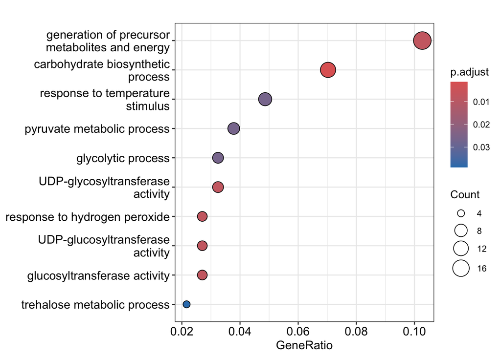

```r
dotplot(go_results, showCategory = 10)
```

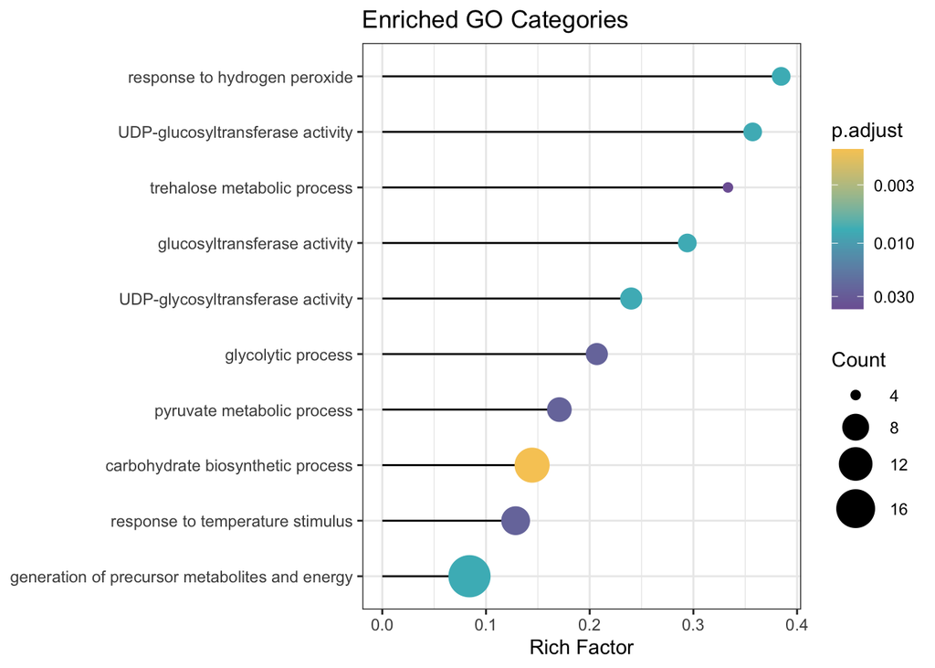

```r
# visualize top GO terms
ggplot(go_results,
       showCategory = 15,
       aes(richFactor, fct_reorder(Description, richFactor))) +
  geom_segment(aes(xend = 0, yend = Description)) +
  geom_point(aes(color = p.adjust, size = Count)) +
  scale_color_gradientn(
    colours = c("#f7ca64", "#46bac2", "#7e62a3"),
    trans = "log10",
    guide = guide_colorbar(reverse = TRUE, order = 1)
  ) +
  scale_size_continuous(range = c(2, 10)) +
  xlab("Rich Factor") +
  ylab(NULL) +
  ggtitle("Enriched GO Categories") +
  theme_bw()
```

#### KEGG

Run KEGG enrichment on the same gene list.

```r
# Run our KEGG enrichment
kegg_results <- clusterProfiler::enrichKEGG(gene = peak_genes,
                           organism = 'sce' #options: https://www.genome.jp/kegg/catalog/org_list.html
                           )
```

```
## Reading KEGG annotation online: "https://rest.kegg.jp/link/sce/pathway"...
```

```
## Reading KEGG annotation online: "https://rest.kegg.jp/list/pathway/sce"...
```

```r
# take a peak at the results
head(kegg_results)
```

```
##            category              subcategory       ID
## sce00500 Metabolism  Carbohydrate metabolism sce00500
## sce01110 Metabolism Global and overview maps sce01110
## sce00520 Metabolism  Carbohydrate metabolism sce00520
## sce01200 Metabolism Global and overview maps sce01200
## sce01250 Metabolism Global and overview maps sce01250
## sce01230 Metabolism Global and overview maps sce01230
##                                                                                     Description
## sce00500               Starch and sucrose metabolism - Saccharomyces cerevisiae (budding yeast)
## sce01110       Biosynthesis of secondary metabolites - Saccharomyces cerevisiae (budding yeast)
## sce00520 Amino sugar and nucleotide sugar metabolism - Saccharomyces cerevisiae (budding yeast)
## sce01200                           Carbon metabolism - Saccharomyces cerevisiae (budding yeast)
## sce01250           Biosynthesis of nucleotide sugars - Saccharomyces cerevisiae (budding yeast)
## sce01230                 Biosynthesis of amino acids - Saccharomyces cerevisiae (budding yeast)
##          GeneRatio  BgRatio       pvalue     p.adjust       qvalue
## sce00500     10/63  41/2467 3.425725e-08 1.918406e-06 1.514531e-06
## sce01110     21/63 351/2467 8.194181e-05 2.294371e-03 1.811345e-03
## sce00520      6/63  34/2467 1.675945e-04 3.128431e-03 2.469814e-03
## sce01200     10/63 112/2467 4.166225e-04 5.832714e-03 4.604775e-03
## sce01250      4/63  23/2467 2.376006e-03 2.661127e-02 2.100890e-02
## sce01230      9/63 125/2467 3.814592e-03 3.560286e-02 2.810752e-02
##                                                                                                                                                                           geneID
## sce00500                                                                                         YBR126C/YCL040W/YDR074W/YEL011W/YFR015C/YFR053C/YKL035W/YLR258W/YLR342W/YML100W
## sce01110 YBR126C/YCL040W/YCR012W/YDL182W/YDR074W/YEL011W/YFR015C/YFR053C/YGR060W/YGR088W/YGR254W/YJL045W/YJR148W/YKL060C/YKL035W/YLR157C/YLR258W/YML100W/YOL126C/YOR136W/YPL111W
## sce00520                                                                                                                         YBR023C/YCL040W/YFR053C/YKL104C/YKL035W/YML087C
## sce01200                                                                                         YCL040W/YCR012W/YFR053C/YGL062W/YGR088W/YGR254W/YJL045W/YKL060C/YOL126C/YOR136W
## sce01250                                                                                                                                         YCL040W/YFR053C/YKL104C/YKL035W
## sce01230                                                                                                 YCR012W/YDL182W/YGL062W/YGR254W/YJR148W/YKL060C/YOR136W/YPL111W/YPR035W
##          Count
## sce00500    10
## sce01110    21
## sce00520     6
## sce01200    10
## sce01250     4
## sce01230     9
```

```r
# create a table for the html file
data.frame(kegg_results) %>% reactable::reactable()
```

|  | category | subcategory | ID | Description | GeneRatio | BgRatio | pvalue | p.adjust | qvalue | geneID | Count |
| --- | --- | --- | --- | --- | --- | --- | --- | --- | --- | --- | --- |
| sce00500 | Metabolism | Carbohydrate metabolism | sce00500 | Starch and sucrose metabolism - Saccharomyces cerevisiae (budding yeast) | 10/63 | 41/2467 | 3.42572535089663e-08 | 1.91840619650211e-06 | 1.51453120776483e-06 | YBR126C/YCL040W/YDR074W/YEL011W/YFR015C/YFR053C/YKL035W/YLR258W/YLR342W/YML100W | 10 |
| sce01110 | Metabolism | Global and overview maps | sce01110 | Biosynthesis of secondary metabolites - Saccharomyces cerevisiae (budding yeast) | 21/63 | 351/2467 | 8.19418129682059e-05 | 0.00229437076310977 | 0.00181134533929718 | YBR126C/YCL040W/YCR012W/YDL182W/YDR074W/YEL011W/YFR015C/YFR053C/YGR060W/YGR088W/YGR254W/YJL045W/YJR148W/YKL060C/YKL035W/YLR157C/YLR258W/YML100W/YOL126C/YOR136W/YPL111W | 21 |
| sce00520 | Metabolism | Carbohydrate metabolism | sce00520 | Amino sugar and nucleotide sugar metabolism - Saccharomyces cerevisiae (budding yeast) | 6/63 | 34/2467 | 0.000167594541541083 | 0.00312843144210021 | 0.0024698142963949 | YBR023C/YCL040W/YFR053C/YKL104C/YKL035W/YML087C | 6 |
| sce01200 | Metabolism | Global and overview maps | sce01200 | Carbon metabolism - Saccharomyces cerevisiae (budding yeast) | 10/63 | 112/2467 | 0.000416622454944822 | 0.00583271436922751 | 0.00460477450202171 | YCL040W/YCR012W/YFR053C/YGL062W/YGR088W/YGR254W/YJL045W/YKL060C/YOL126C/YOR136W | 10 |
| sce01250 | Metabolism | Global and overview maps | sce01250 | Biosynthesis of nucleotide sugars - Saccharomyces cerevisiae (budding yeast) | 4/63 | 23/2467 | 0.00237600622886357 | 0.0266112697632719 | 0.0210088971815305 | YCL040W/YFR053C/YKL104C/YKL035W | 4 |
| sce01230 | Metabolism | Global and overview maps | sce01230 | Biosynthesis of amino acids - Saccharomyces cerevisiae (budding yeast) | 9/63 | 125/2467 | 0.00381459189890946 | 0.0356028577231549 | 0.0281075192551223 | YCR012W/YDL182W/YGL062W/YGR254W/YJR148W/YKL060C/YOR136W/YPL111W/YPR035W | 9 |

```r
# Remove " - Saccharomyces cerevesiae" from each description entry
kegg_results@result$Description <- kegg_results@result$Description %>% print() %>% str_replace_all(., fixed(" - Saccharomyces cerevisiae"), "")
```

```
##  [1] "Starch and sucrose metabolism - Saccharomyces cerevisiae (budding yeast)"
##  [2] "Biosynthesis of secondary metabolites - Saccharomyces cerevisiae (budding yeast)"
##  [3] "Amino sugar and nucleotide sugar metabolism - Saccharomyces cerevisiae (budding yeast)"
##  [4] "Carbon metabolism - Saccharomyces cerevisiae (budding yeast)"
##  [5] "Biosynthesis of nucleotide sugars - Saccharomyces cerevisiae (budding yeast)"
##  [6] "Biosynthesis of amino acids - Saccharomyces cerevisiae (budding yeast)"
##  [7] "Citrate cycle (TCA cycle) - Saccharomyces cerevisiae (budding yeast)"
##  [8] "Glycolysis / Gluconeogenesis - Saccharomyces cerevisiae (budding yeast)"
##  [9] "Meiosis - yeast - Saccharomyces cerevisiae (budding yeast)"
## [10] "Fructose and mannose metabolism - Saccharomyces cerevisiae (budding yeast)"
## [11] "Galactose metabolism - Saccharomyces cerevisiae (budding yeast)"
## [12] "Glyoxylate and dicarboxylate metabolism - Saccharomyces cerevisiae (budding yeast)"
## [13] "Pyruvate metabolism - Saccharomyces cerevisiae (budding yeast)"
## [14] "Alanine, aspartate and glutamate metabolism - Saccharomyces cerevisiae (budding yeast)"
## [15] "Arginine biosynthesis - Saccharomyces cerevisiae (budding yeast)"
```

[output cut: 41 more lines]

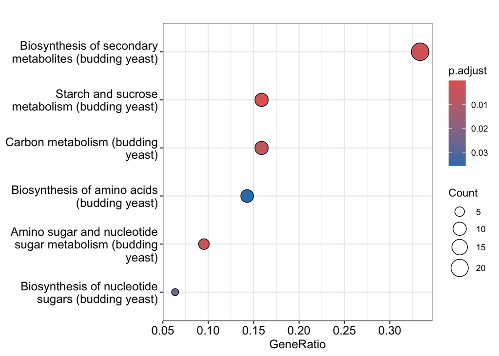

```r
# browseKEGG(kegg_results, 'sce04213')  # longevity
# browseKEGG(kegg_results, 'sce00500')  # Starch and sucrose metabolism


dotplot(kegg_results, showCategory = 10)
```

### Motif Analysis

The MEME-suite that we used in a previous motif analysis exercise has a specific algorithm for ChIP-seq analysis, called MEME-ChIP. This workflow hasn’t been implemented in the `memes` package in R yet, but can be done in the website at https://meme-suite.org/meme/tools/meme-chip. You can upload a fasta file of the peak summits to be analyzed.

First, let’s extract the sequences corresponding to the annotated peak ranges. We will use the `get_sequence` function from the `memes` package for this. This function requires a BSgenome database to pull sequences from, so it has been loaded in.

```r
# load in sacCer3 genome
sacCer3.genome <- BSgenome.Scerevisiae.UCSC.sacCer3::BSgenome.Scerevisiae.UCSC.sacCer3

# use memes to retrieve sequences of peaks
peak_seqs <- memes::get_sequence(MSN24_ESR_t20vst0_peaks_GR, sacCer3.genome)
```

Let’s create a folder to which we can save output files.

```r
# Choose output directory for the output files to be saved
out_dir <- path.expand("~/Desktop/Genomic_Data_Analysis/Analysis/memes/ChIP_msn24/")

# Create out_dir directory if doesn't already exist
if (!dir.exists(out_dir)) {
  dir.create(out_dir, recursive = TRUE)
}
```

#### Streme

We can use Streme to look for enriched motifs in the promoters of those genes corresponding to enrichment peaks. Once Streme finishes, we can check out the .html output file in the output folder.

```r
# Run Streme
streme_msn24_ChIP <- runStreme(peak_seqs,
        control="shuffle",
        minw = 5, # default is 8, for yeast I use 5
        maxw= 20, #default is 15, for yeast I use 20
        parse_genomic_coord=FALSE,
        silent=TRUE,
        outdir = path.expand(paste0(out_dir, "streme_msn24_ChIP_diauxic"))
        )
# Display Streme results
streme_msn24_ChIP |> reactable::reactable()
```

|  | motif | name | altname | family | organism | consensus | alphabet | strand | icscore | nsites | bkgsites | pval | qval | eval | type | pseudocount | bkg | width | initial_width | seed | score_threshold | pos_count | neg_count | log_pval | log_evalue | evalue | dtc | bernoulli | train_pos_count | … |
| --- | --- | --- | --- | --- | --- | --- | --- | --- | --- | --- | --- | --- | --- | --- | --- | --- | --- | --- | --- | --- | --- | --- | --- | --- | --- | --- | --- | --- | --- | --- |
| m1_YAWTR | {'name': 'm1_YAWTR', 'altname': 'STREME-1', 'family': [], 'organism': [], 'motif': [[4, 141, 73, 4, 72], [72, 3, 3, 3, 3], [3, 3, 3, 3, 72], [72, 4, 72, 141, 4]], 'alphabet': 'DNA', 'type': 'PCM', 'ic… | m1_YAWTR | STREME-1 | NA | NA | YAWTR | DNA | +- | 5.30746487762124 | 151 | NA | 0.0054 | NA | NA | PCM | 0 | [0.279, 0.221, 0.221, 0.279] | 5 | 5 | CATTA | 6.78383 | 17 | 8 | -2.26471 | -1.36162 | 4.3e-002 | -1 | 0.5 | 134 | … |
| m2_AAAAAAAAAAAAAAAAAGA | {'name': 'm2_AAAAAAAAAAAAAAAAAGA', 'altname': 'STREME-2', 'family': [], 'organism': [], 'motif': [[75, 69, 66, 67, 70, 58, 66, 74, 57, 72, 59, 53, 58, 55, 60, 59, 47, 0, 72], [1, 1, 5, 0, 0, 1, 1, 0, … | m2_AAAAAAAAAAAAAAAAAGA | STREME-2 | NA | NA | AAAAAAAAAAARAAAAAGA | DNA | +- | 22.0929272895141 | 77 | NA | 0.01 | NA | NA | PCM | 0 | [0.279, 0.221, 0.221, 0.279] | 19 | 12 | AAAAAAAAAAAAAAAAAGA | 13.1178 | 6 | 0 | -1.9853 | -1.08221 | 8.3e-002 | -1 | 0.5 | 71 | … |
| m3_CAACAACAACAGCRHCAR | {'name': 'm3_CAACAACAACAGCRHCAR', 'altname': 'STREME-3', 'family': [], 'organism': [], 'motif': [[3, 50, 33, 0, 41, 44, 0, 53, 39, 5, 48, 13, 10, 32, 17, 0, 38, 16], [44, 4, 5, 43, 11, 7, 54, 0, 12, 3… | m3_CAACAACAACAGCRHCAR | STREME-3 | NA | NA | CAACAACAACAGCRHCWR | DNA | +- | 15.0465153610225 | 57 | NA | 0.024 | NA | NA | PCM | 0 | [0.279, 0.221, 0.221, 0.279] | 18 | 17 | CAACAACAACAGCATCAG | 11.6811 | 5 | 0 | -1.62122 | -0.718127 | 1.9e-001 | -1 | 0.5 | 52 | … |
| m4_AGGGG | {'name': 'm4_AGGGG', 'altname': 'STREME-4', 'family': [], 'organism': [], 'motif': [[123, 3, 3, 3, 3], [3, 3, 3, 3, 3], [3, 123, 123, 123, 123], [3, 3, 3, 3, 3]], 'alphabet': 'DNA', 'type': 'PCM', 'ic… | m4_AGGGG | STREME-4 | NA | NA | AGGGG | DNA | +- | 7.6641637465114 | 132 | NA | 0.026 | NA | NA | PCM | 0 | [0.279, 0.221, 0.221, 0.279] | 5 | 5 | AGGGG | 9.9892 | 17 | 10 | -1.58814 | -0.685049 | 2.1e-001 | -1 | 0.5 | 115 | … |
| m5_AAGAAAAAAAAC | {'name': 'm5_AAGAAAAAAAAC', 'altname': 'STREME-5', 'family': [], 'organism': [], 'motif': [[49, 51, 5, 47, 47, 47, 42, 40, 41, 46, 41, 11], [0, 0, 0, 1, 0, 1, 4, 2, 4, 2, 5, 30], [0, 0, 46, 1, 4, 1, 4… | m5_AAGAAAAAAAAC | STREME-5 | NA | NA | AAGAAAAAAAAC | DNA | +- | 15.8882786882752 | 51 | NA | 0.047 | NA | NA | PCM | 0 | [0.279, 0.221, 0.221, 0.279] | 12 | 11 | AAGAAAAAAAAC | 11.6894 | 6 | 1 | -1.33209 | -0.428996 | 3.7e-001 | -1 | 0.5 | 45 | … |
| m6_AGCCGCCGHG | {'name': 'm6_AGCCGCCGHG', 'altname': 'STREME-6', 'family': [], 'organism': [], 'motif': [[26, 1, 0, 0, 0, 2, 0, 3, 11, 5], [5, 0, 22, 28, 0, 27, 31, 0, 7, 0], [0, 30, 0, 2, 31, 0, 0, 26, 2, 18], [0, 0… | m6_AGCCGCCGHG | STREME-6 | NA | NA | AGYCGCCGNK | DNA | +- | 13.0775941218096 | 31 | NA | 0.5 | NA | NA | PCM | 0 | [0.279, 0.221, 0.221, 0.279] | 10 | 8 | AGCCGCCGTG | 12.8095 | 2 | 1 | -0.30103 | 0.60206 | 4.0e+000 | -1 | 0.5 | 29 | … |
| m7_AAASGAAAMKAMAMBWVAWW | {'name': 'm7_AAASGAAAMKAMAMBWVAWW', 'altname': 'STREME-7', 'family': [], 'organism': [], 'motif': [[32, 32, 31, 6, 3, 39, 28, 42, 24, 0, 31, 23, 33, 23, 5, 17, 15, 23, 18, 15], [0, 0, 3, 17, 0, 2, 5, … | m7_AAASGAAAMKAMAMBWVAWW | STREME-7 | NA | NA | AAASGAAAMKAMAMNWNANW | DNA | +- | 16.0964103466847 | 42 | NA | 0.5 | NA | NA | PCM | 0 | [0.279, 0.221, 0.221, 0.279] | 20 | 15 | AAACGAAACGAAACGAAACT | 11.8922 | 2 | 1 | -0.30103 | 0.60206 | 4.0e+000 | -1 | 0.5 | 40 | … |
| m8_ACGACATCGCT | {'name': 'm8_ACGACATCGCT', 'altname': 'STREME-8', 'family': [], 'organism': [], 'motif': [[26, 1, 3, 21, 0, 28, 0, 4, 4, 2, 3], [3, 26, 0, 1, 27, 0, 1, 25, 2, 22, 1], [0, 2, 25, 3, 1, 1, 2, 0, 21, 0, … | m8_ACGACATCGCT | STREME-8 | NA | NA | ACGACATCGCT | DNA | +- | 13.799843841244 | 29 | NA | 0.76 | NA | NA | PCM | 0 | [0.279, 0.221, 0.221, 0.279] | 11 | 7 | ACGACATCGCT | 12.2708 | 1 | 1 | -0.121422 | 0.781668 | 6.0e+000 | -1 | 0.5 | 28 | … |

#### TomTom

Finally, use TomTom to see which TFs those motifs might correspond to. We can check the .html output file for TomTom as well.

```r
# path to yeastract
db_destination <-
  path.expand("~/Desktop/Genomic_Data_Analysis/Reference/YEASTRACT_20130918.meme")

# Run TomTom on motifs found by runStreme()
streme_tomtom_msn24_ChIP <-
  runTomTom(
    input = streme_msn24_ChIP,
    database = db_destination,
    outdir = path.expand(paste0(out_dir, "tomtom_streme_msn24_ChIP"))
  )
```

# Questions

1. Based on the results obtained from the MACS2 analysis, what can you infer about the genomic regions where Msn2 is binding?
2. If you were designing a ChIP-seq experiment to study Msn2 binding under different conditions, what factors would you consider in your experimental design
3. What can ChIP-seq tell us about Msn2 that our previous analyses cannot?

Be sure to knit this file into a pdf or html file once you’re finished.

**R version 4.3.1 (2023-06-16)**

**Platform:** aarch64-apple-darwin20 (64-bit)

**locale:** en_US.UTF-8

**attached base packages:** *stats4*, *stats*, *graphics*, *grDevices*, *utils*, *datasets*, *methods* and *base*

**other attached packages:** *reactable(v.0.4.4)*, *ggimage(v.0.3.3)*, *clusterProfiler(v.4.10.0)*, *universalmotif(v.1.20.0)*, *memes(v.1.10.0)*, *biomaRt(v.2.58.0)*, *curl(v.5.1.0)*, *Rsubread(v.2.16.0)*, *Rfastp(v.1.12.0)*, *knitr(v.1.44)*, *lubridate(v.1.9.3)*, *forcats(v.1.0.0)*, *stringr(v.1.5.0)*, *dplyr(v.1.1.3)*, *purrr(v.1.0.2)*, *readr(v.2.1.4)*, *tidyr(v.1.3.0)*, *tibble(v.3.2.1)*, *ggplot2(v.3.4.4)*, *tidyverse(v.2.0.0)*, *ChIPseeker(v.1.38.0)*, *BSgenome.Scerevisiae.UCSC.sacCer3(v.1.4.0)*, *BSgenome(v.1.70.0)*, *rtracklayer(v.1.62.0)*, *BiocIO(v.1.12.0)*, *Biostrings(v.2.70.1)*, *XVector(v.0.42.0)*, *TxDb.Scerevisiae.UCSC.sacCer3.sgdGene(v.3.2.2)*, *GenomicFeatures(v.1.54.1)*, *AnnotationDbi(v.1.64.0)*, *Biobase(v.2.62.0)*, *GenomicRanges(v.1.54.0)*, *GenomeInfoDb(v.1.38.0)*, *IRanges(v.2.36.0)*, *S4Vectors(v.0.40.0)*, *BiocGenerics(v.0.48.0)* and *pacman(v.0.5.1)*

**loaded via a namespace (and not attached):** *fs(v.1.6.3)*, *matrixStats(v.1.0.0)*, *bitops(v.1.0-7)*, *enrichplot(v.1.22.0)*, *HDO.db(v.0.99.1)*, *httr(v.1.4.7)*, *RColorBrewer(v.1.1-3)*, *tools(v.4.3.1)*, *utf8(v.1.2.4)*, *R6(v.2.5.1)*, *lazyeval(v.0.2.2)*, *withr(v.2.5.1)*, *prettyunits(v.1.2.0)*, *gridExtra(v.2.3)*, *cli(v.3.6.1)*, *scatterpie(v.0.2.1)*, *labeling(v.0.4.3)*, *sass(v.0.4.7)*, *Rsamtools(v.2.18.0)*, *yulab.utils(v.0.1.0)*, *gson(v.0.1.0)*, *ggupset(v.0.3.0)*, *DOSE(v.3.28.0)*, *R.utils(v.2.12.2)*, *plotrix(v.3.8-2)*, *rstudioapi(v.0.15.0)*, *RSQLite(v.2.3.1)*, *generics(v.0.1.3)*, *gridGraphics(v.0.5-1)*, *TxDb.Hsapiens.UCSC.hg19.knownGene(v.3.2.2)*, *gtools(v.3.9.4)*, *crosstalk(v.1.2.0)*, *GO.db(v.3.18.0)*, *Matrix(v.1.6-1.1)*, *fansi(v.1.0.5)*, *abind(v.1.4-5)*, *R.methodsS3(v.1.8.2)*, *lifecycle(v.1.0.3)*, *yaml(v.2.3.7)*, *SummarizedExperiment(v.1.32.0)*, *gplots(v.3.1.3)*, *qvalue(v.2.34.0)*, *SparseArray(v.1.2.0)*, *BiocFileCache(v.2.10.0)*, *grid(v.4.3.1)*, *blob(v.1.2.4)*, *promises(v.1.2.1)*, *crayon(v.1.5.2)*, *lattice(v.0.22-5)*, *cowplot(v.1.1.1)*, *KEGGREST(v.1.42.0)*, *magick(v.2.8.1)*, *pillar(v.1.9.0)*, *fgsea(v.1.28.0)*, *rjson(v.0.2.21)*, *boot(v.1.3-28.1)*, *codetools(v.0.2-19)*, *fastmatch(v.1.1-4)*, *glue(v.1.6.2)*, *ggfun(v.0.1.3)*, *data.table(v.1.14.8)*, *vctrs(v.0.6.4)*, *png(v.0.1-8)*, *treeio(v.1.26.0)*, *testthat(v.3.2.0)*, *gtable(v.0.3.4)*, *reactR(v.0.5.0)*, *cachem(v.1.0.8)*, *xfun(v.0.40)*, *S4Arrays(v.1.2.0)*, *mime(v.0.12)*, *tidygraph(v.1.2.3)*, *interactiveDisplayBase(v.1.40.0)*, *ellipsis(v.0.3.2)*, *nlme(v.3.1-163)*, *ggtree(v.3.10.0)*, *bit64(v.4.0.5)*, *progress(v.1.2.2)*, *filelock(v.1.0.2)*, *rprojroot(v.2.0.3)*, *bslib(v.0.5.1)*, *KernSmooth(v.2.23-22)*, *colorspace(v.2.1-0)*, *DBI(v.1.1.3)*, *processx(v.3.8.2)*, *tidyselect(v.1.2.0)*, *bit(v.4.0.5)*, *compiler(v.4.3.1)*, *xml2(v.1.3.5)*, *desc(v.1.4.2)*, *DelayedArray(v.0.28.0)*, *shadowtext(v.0.1.2)*, *scales(v.1.2.1)*, *caTools(v.1.18.2)*, *rappdirs(v.0.3.3)*, *digest(v.0.6.33)*, *rmarkdown(v.2.25)*, *htmltools(v.0.5.6.1)*, *pkgconfig(v.2.0.3)*, *MatrixGenerics(v.1.14.0)*, *dbplyr(v.2.3.4)*, *fastmap(v.1.1.1)*, *rlang(v.1.1.1)*, *htmlwidgets(v.1.6.2)*, *shiny(v.1.7.5.1)*, *farver(v.2.1.1)*, *jquerylib(v.0.1.4)*, *jsonlite(v.1.8.7)*, *BiocParallel(v.1.36.0)*, *R.oo(v.1.25.0)*, *GOSemSim(v.2.28.0)*, *RCurl(v.1.98-1.12)*, *magrittr(v.2.0.3)*, *GenomeInfoDbData(v.1.2.11)*, *ggplotify(v.0.1.2)*, *patchwork(v.1.1.3)*, *munsell(v.0.5.0)*, *Rcpp(v.1.0.11)*, *ape(v.5.7-1)*, *viridis(v.0.6.4)*, *stringi(v.1.7.12)*, *ggraph(v.2.1.0)*, *brio(v.1.1.3)*, *zlibbioc(v.1.48.0)*, *MASS(v.7.3-60)*, *AnnotationHub(v.3.10.0)*, *plyr(v.1.8.9)*, *ggseqlogo(v.0.1)*, *parallel(v.4.3.1)*, *HPO.db(v.0.99.2)*, *ggrepel(v.0.9.4)*, *org.Sc.sgd.db(v.3.18.0)*, *graphlayouts(v.1.0.1)*, *splines(v.4.3.1)*, *pander(v.0.6.5)*, *hms(v.1.1.3)*, *ps(v.1.7.5)*, *igraph(v.1.5.1)*, *reshape2(v.1.4.4)*, *pkgload(v.1.3.3)*, *BiocVersion(v.3.18.0)*, *XML(v.3.99-0.14)*, *evaluate(v.0.22)*, *BiocManager(v.1.30.22)*, *tzdb(v.0.4.0)*, *tweenr(v.2.0.2)*, *httpuv(v.1.6.12)*, *polyclip(v.1.10-6)*, *ggforce(v.0.4.1)*, *xtable(v.1.8-4)*, *restfulr(v.0.0.15)*, *tidytree(v.0.4.5)*, *MPO.db(v.0.99.7)*, *later(v.1.3.1)*, *viridisLite(v.0.4.2)*, *aplot(v.0.2.2)*, *memoise(v.2.0.1)*, *GenomicAlignments(v.1.38.0)*, *timechange(v.0.2.0)* and *cmdfun(v.1.0.2)*